# Projet de Timeo et Charles

Author

Timeo Bossuet, Charles Ganne

# Chargement et découverte du jeu de données

Ce projet a pour objectif de mener l’étude descriptive uni- et bi-dimensionnelle du jeu de données `DataGym3MIC` disponible sous Moodle.

*Remarque : penser à enlever les “#|eval: false” au fur et à mesure de l’avancement dans le projet pour avoir les résultats dans le compte-rendu final.*

```r
# options possibles (tout ça pour le compte rendu final)
#| echo: true #(#| echo: false) : inclure le code (ou pas)
#| eval: true #(#| eval: false) : évalue le code (ou pas)
#| warning: true #(#| warning: false) : affiche les warnings (ou pas)
#| message: true #(#| message: false) : affiche les messages (ou pas)

SalleDeSport <- read.table("DataGym3MIC.txt", header = T, stringsAsFactors = T) # charger le jeu de données
head(SalleDeSport) # voir les 6 premières lignes
```

```
  gender weight height duration calories  fat water level   bmi
1   Male   88.3   1.71     1.69     1313 12.6   3.5     3 30.20
2 Female   74.9   1.53     1.30      883 33.9   2.1     2 32.00
3 Female   68.1   1.66     1.11      677 33.4   2.3     2 24.71
4   Male   53.2   1.70     0.59      532 28.8   2.1     1 18.41
5   Male   46.1   1.79     0.64      556 29.2   2.8     1 14.39
6 Female   58.0   1.68     1.59     1116 15.5   2.7     3 20.55
```

```r
dim(SalleDeSport) # voir les dimensions du jeu de données
```

```
[1] 973   9
```

```r
summary(SalleDeSport)
```

```
    gender        weight           height         duration        calories
 Female:462   Min.   : 40.00   Min.   :1.500   Min.   :0.500   Min.   : 303.0
 Male  :511   1st Qu.: 58.10   1st Qu.:1.620   1st Qu.:1.040   1st Qu.: 720.0
              Median : 70.00   Median :1.710   Median :1.260   Median : 893.0
              Mean   : 73.85   Mean   :1.723   Mean   :1.256   Mean   : 905.4
              3rd Qu.: 86.00   3rd Qu.:1.800   3rd Qu.:1.460   3rd Qu.:1076.0
              Max.   :129.90   Max.   :2.000   Max.   :2.000   Max.   :1783.0
      fat            water           level           bmi
 Min.   :10.00   Min.   :1.500   Min.   :1.00   Min.   :12.32
 1st Qu.:21.30   1st Qu.:2.200   1st Qu.:1.00   1st Qu.:20.11
 Median :26.20   Median :2.600   Median :2.00   Median :24.16
 Mean   :24.98   Mean   :2.627   Mean   :1.81   Mean   :24.91
 3rd Qu.:29.30   3rd Qu.:3.100   3rd Qu.:2.00   3rd Qu.:28.56
 Max.   :35.00   Max.   :3.700   Max.   :3.00   Max.   :49.84
```

```r
str(SalleDeSport) # contrôle de la nature de chaque variable
```

```
'data.frame':   973 obs. of  9 variables:
 $ gender  : Factor w/ 2 levels "Female","Male": 2 1 1 2 2 1 2 1 2 2 ...
 $ weight  : num  88.3 74.9 68.1 53.2 46.1 ...
 $ height  : num  1.71 1.53 1.66 1.7 1.79 1.68 1.72 1.51 1.94 1.84 ...
 $ duration: num  1.69 1.3 1.11 0.59 0.64 1.59 1.49 1.27 1.03 1.08 ...
 $ calories: int  1313 883 677 532 556 1116 1385 895 719 808 ...
 $ fat     : num  12.6 33.9 33.4 28.8 29.2 15.5 21.3 30.6 28.9 29.7 ...
 $ water   : num  3.5 2.1 2.3 2.1 2.8 2.7 2.3 1.9 2.6 2.7 ...
 $ level   : int  3 2 2 1 1 3 2 2 2 1 ...
 $ bmi     : num  30.2 32 24.7 18.4 14.4 ...
```

Ce jeu de données comprend des mesures empiriques réalisées sur un échantillon de $973$ usagers d’une salle de sport. Chaque personne est décrite par les variables suivantes :

- *gender* : Sexe du membre de la salle de sport (homme ou femme)
- *weight* : Poids du membre en kilogrammes
- *height* : Taille du membre en mètres
- *duration* : Durée de chaque séance d’entraı̂nement en heures
- *calories* : Total des calories brûlées au cours de chaque séance
- *fat* : Pourcentage de graisse corporelle du membre
- *water* : Consommation quotidienne d’eau pendant les séances d’entraı̂nement
- *level* : Niveau d’expérience, de débutant (1) à expert (3)
- *bmi* : Indice de masse corporelle (IMC), calculé à partir de la taille et du poids

En regardant le résultat de la fonction `str`, on observe que la variable *gender* est qualitative nominale et la variable *level* est qualitative ordinale. De plus, la variable *calories* est quantitative discrète et les autres sont quantitatives continues. Attention, il faut bien préciser à R les variables qui doivent être considérées comme qualitatives. On utilise donc la fonction `as.factor()` sur les variables *gender* et *level*.

```r
SalleDeSport$gender <- factor(SalleDeSport$gender, levels=c("Male","Female"), labels = c("Homme", "Femme"))
SalleDeSport$level <- factor(SalleDeSport$level, levels=c("1","2","3"), labels=c("Débutant","Intermédiaire","Expert"), ordered=TRUE)
```

## Analyse unidimentionnelle

On commence par étudier chaque variable individuellement.

### Variables quantitatives

Pour chaque variable quantitative, on examine des statistiques descriptives (moyenne, médiane, quartiles, etc.). On trace également chaque boxplot :

```r
summary(SalleDeSport[, c("weight","height","duration","calories","fat","water","bmi")])
```

```
     weight           height         duration        calories
 Min.   : 40.00   Min.   :1.500   Min.   :0.500   Min.   : 303.0
 1st Qu.: 58.10   1st Qu.:1.620   1st Qu.:1.040   1st Qu.: 720.0
 Median : 70.00   Median :1.710   Median :1.260   Median : 893.0
 Mean   : 73.85   Mean   :1.723   Mean   :1.256   Mean   : 905.4
 3rd Qu.: 86.00   3rd Qu.:1.800   3rd Qu.:1.460   3rd Qu.:1076.0
 Max.   :129.90   Max.   :2.000   Max.   :2.000   Max.   :1783.0
      fat            water            bmi
 Min.   :10.00   Min.   :1.500   Min.   :12.32
 1st Qu.:21.30   1st Qu.:2.200   1st Qu.:20.11
 Median :26.20   Median :2.600   Median :24.16
 Mean   :24.98   Mean   :2.627   Mean   :24.91
 3rd Qu.:29.30   3rd Qu.:3.100   3rd Qu.:28.56
 Max.   :35.00   Max.   :3.700   Max.   :49.84
```

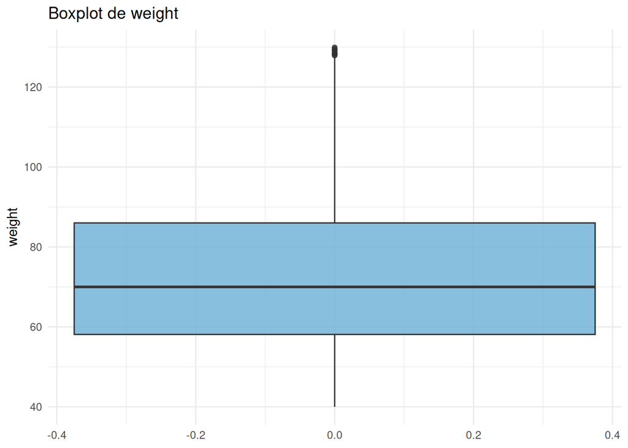

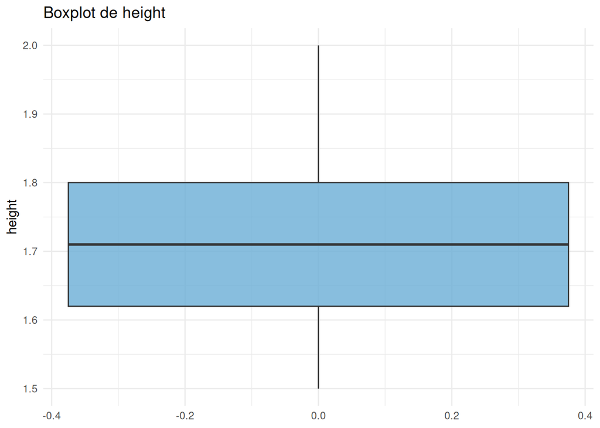

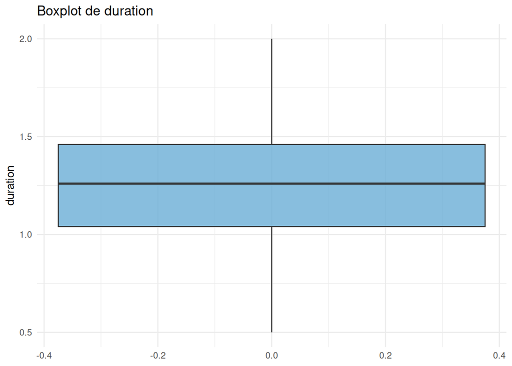

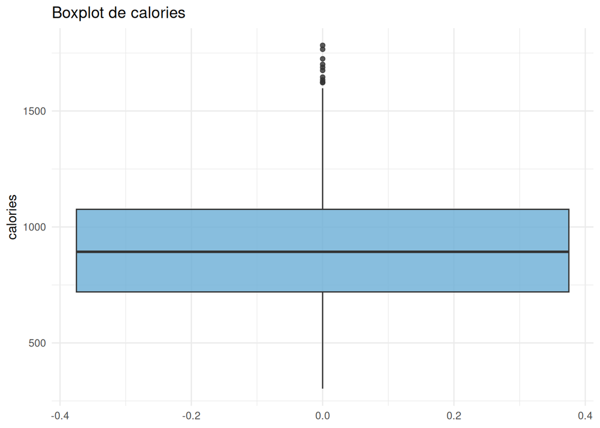

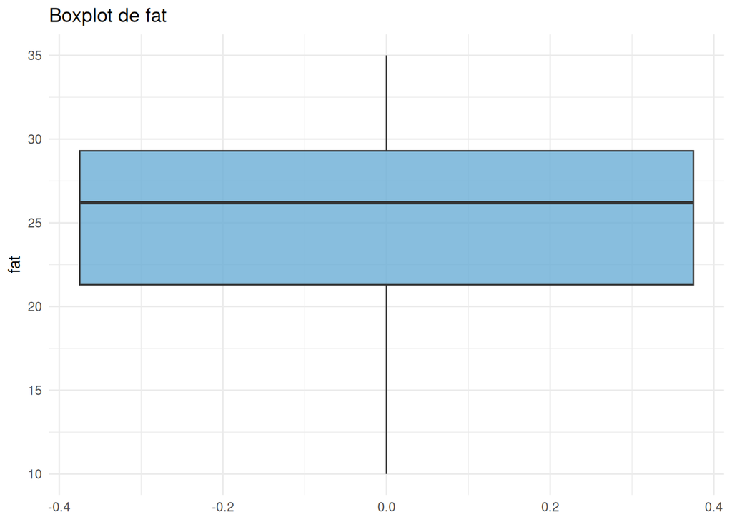

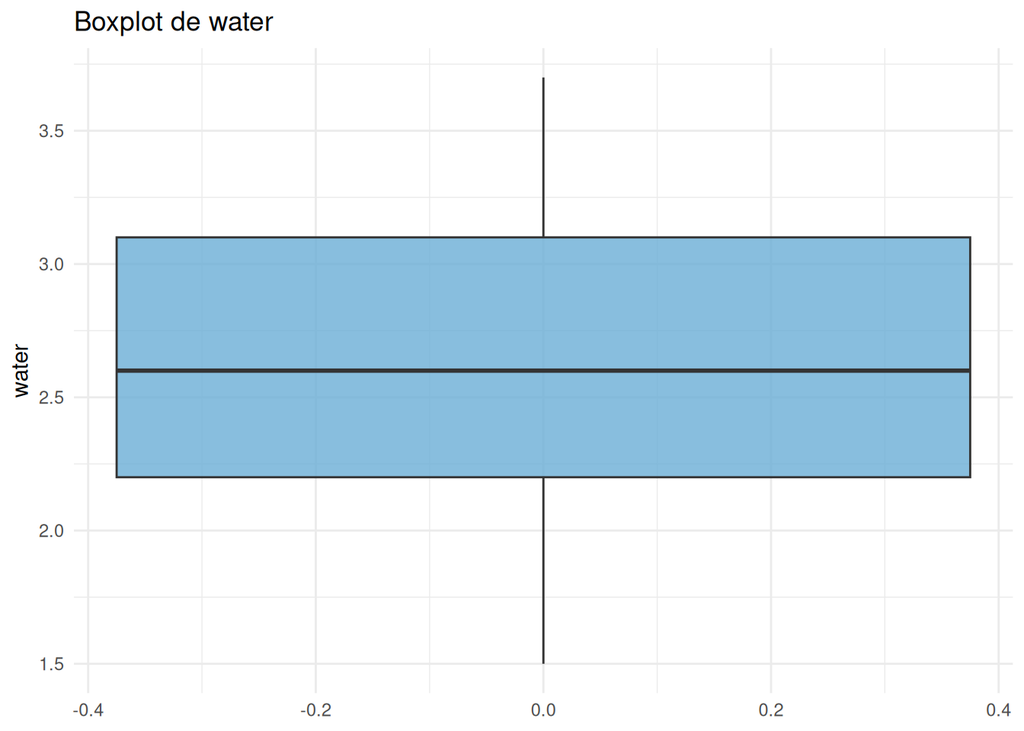

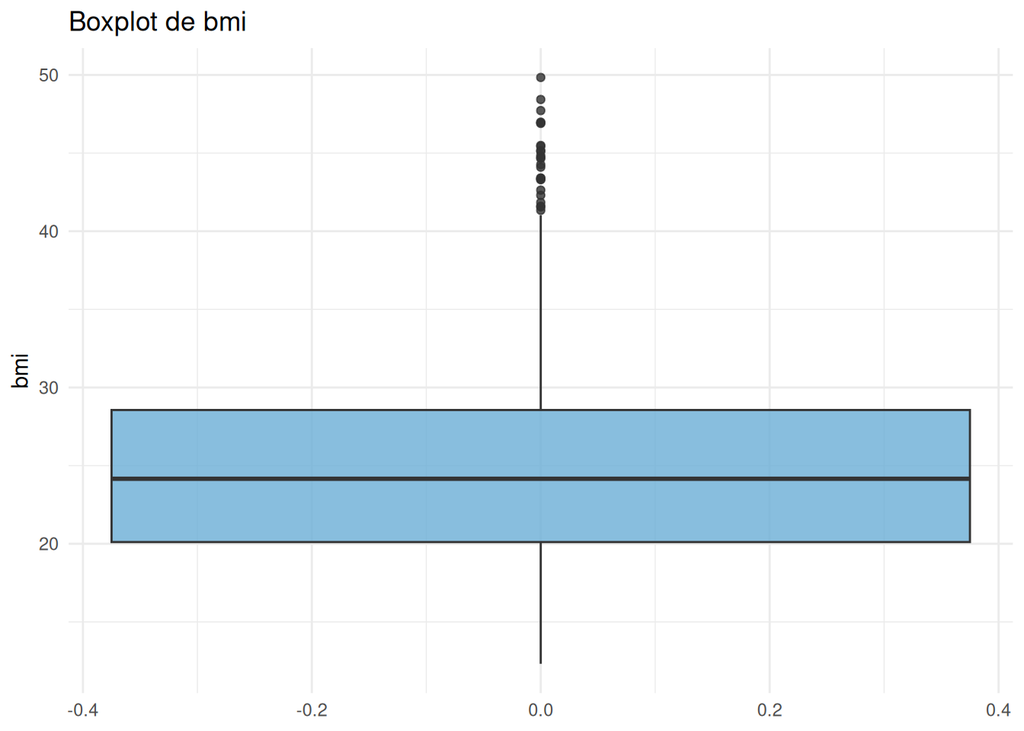

```r
vars <- c("weight","height","duration","calories","fat","water","bmi")

for (v in vars) {
  print(
    ggplot(SalleDeSport, aes(y = .data[[v]])) +
      geom_boxplot(fill = "#6BAED6", alpha = 0.8) +
      theme_minimal() +
      labs(title = paste("Boxplot de", v), y = v, x = NULL)
  )
}
```

Voici maintenant les histogrammes de chaque variable :

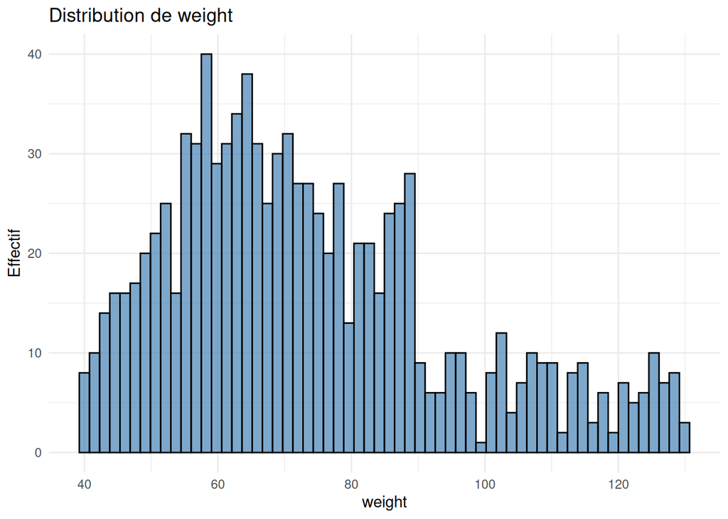

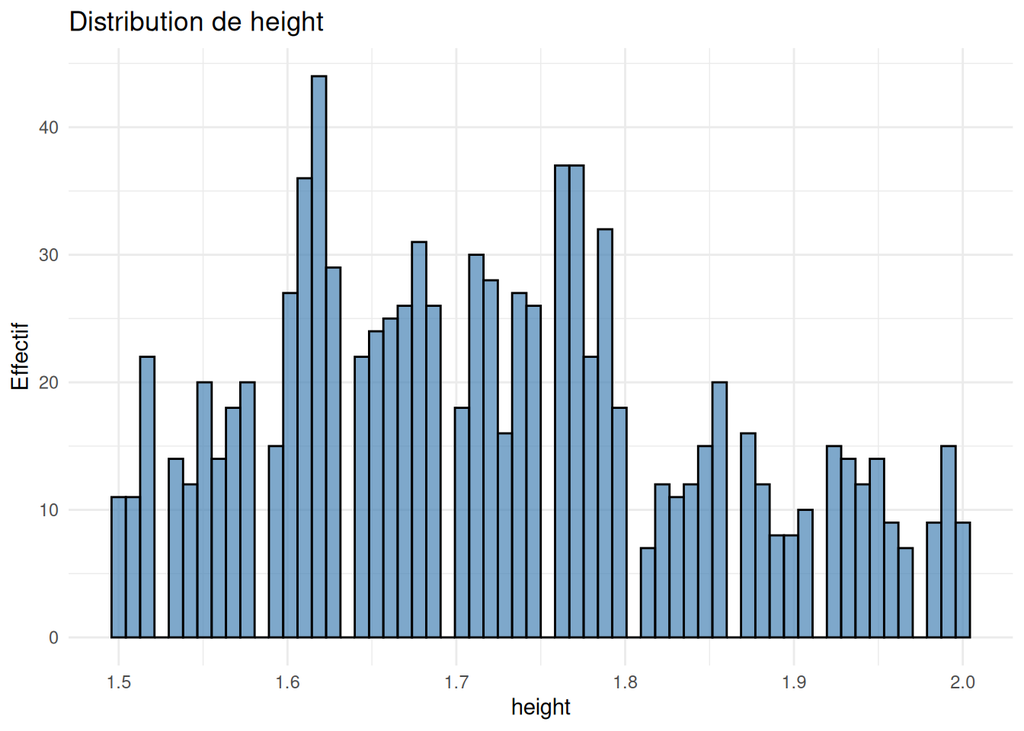

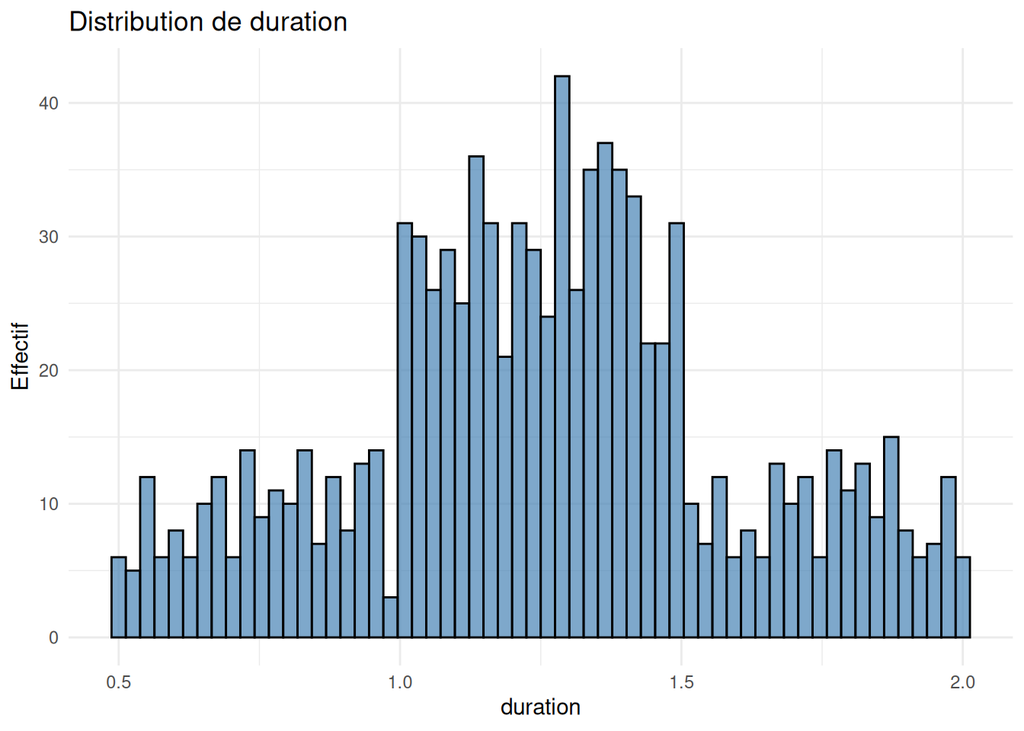

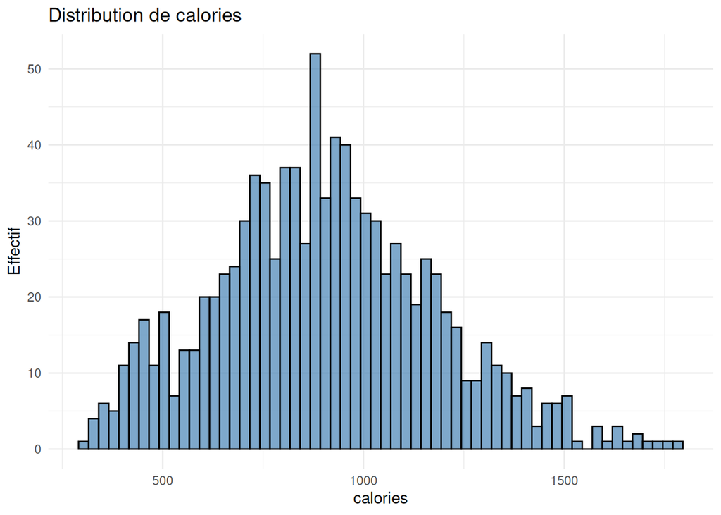

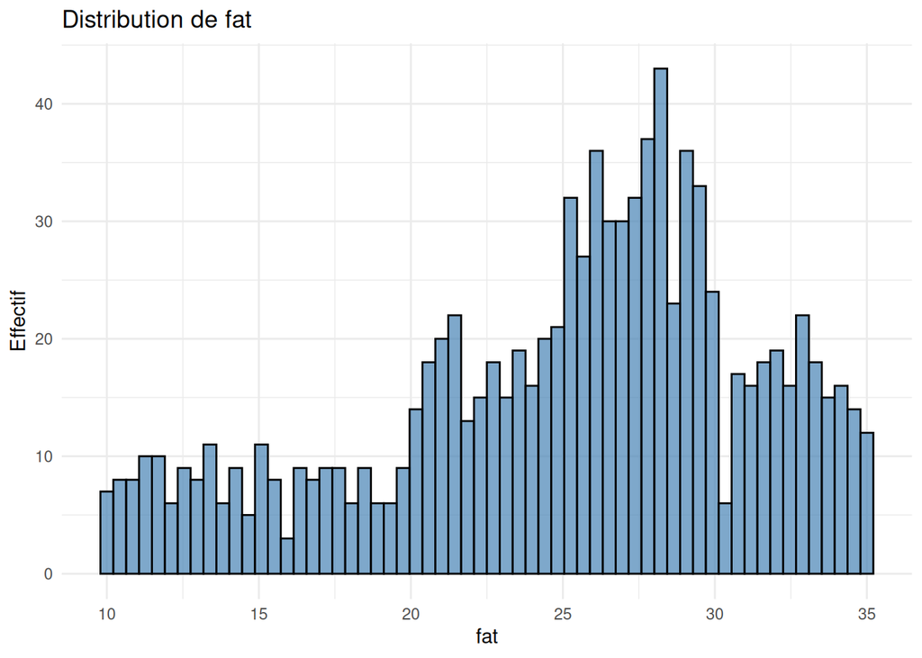

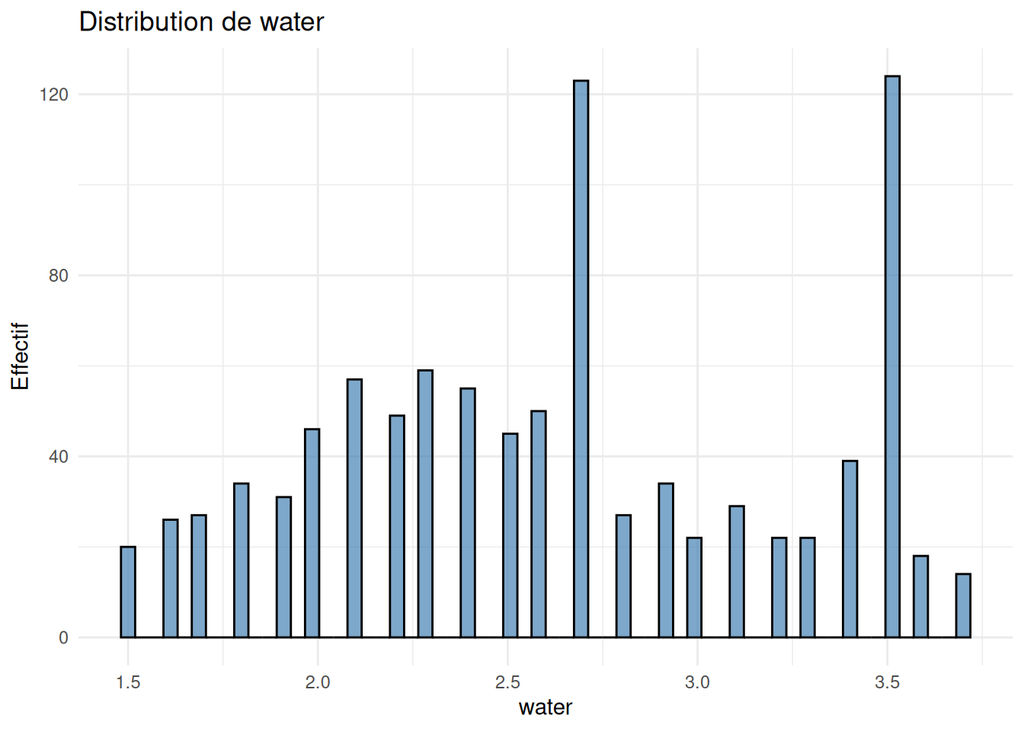

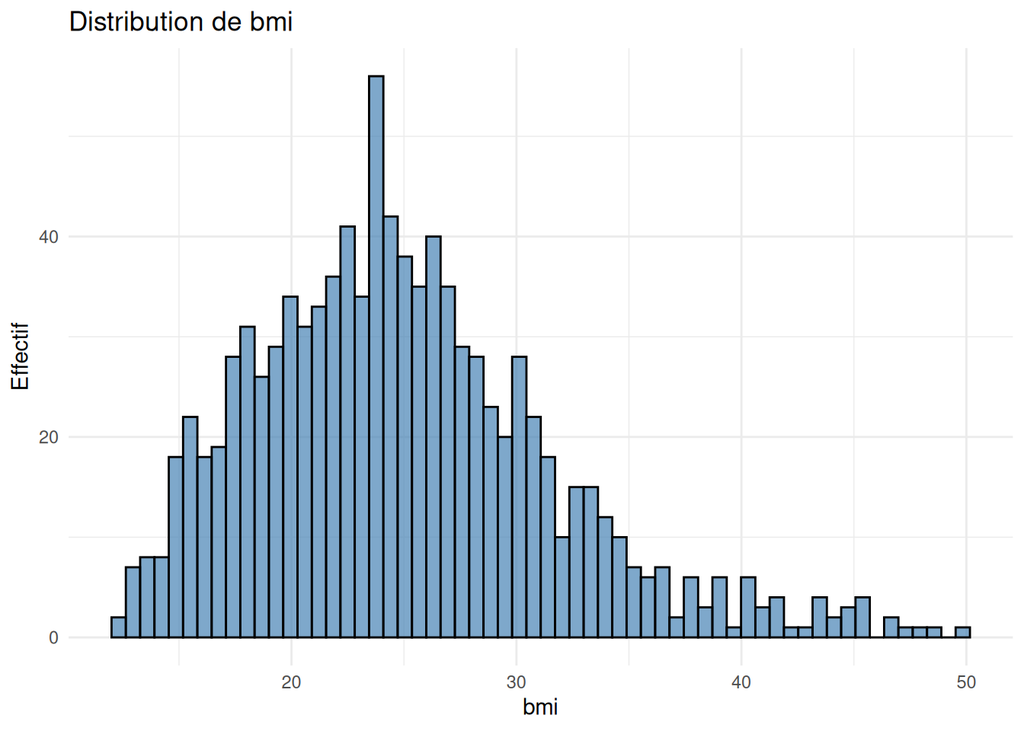

```r
# Liste des variables
vars <- c("weight", "height", "duration", "calories", "fat", "water", "bmi")

# Boucle pour afficher chaque histogramme
for (var in vars) {
  p <- ggplot(SalleDeSport, aes(x = .data[[var]])) +
    geom_histogram(bins = 60, fill = "steelblue", color = "black", alpha = 0.7) +
    labs(title = paste("Distribution de", var),
         x = var, y = "Effectif") +
    theme_minimal()
  print(p)
}
```

#### Poids (weight)

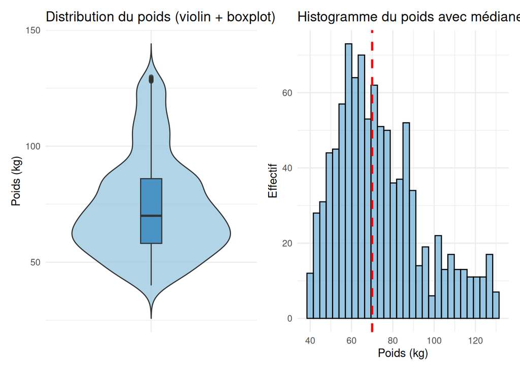

```r
# 1) Violin + boxplot
p_violin_box <- ggplot(SalleDeSport, aes(x = "", y = weight)) +
  geom_violin(fill = "#9ECAE1", alpha = 0.8, trim = FALSE) +
  geom_boxplot(width = 0.12, fill = "#3182BD", alpha = 0.8,
               outlier.alpha = 0.6) +
  theme_minimal() +
  labs(
    title = "Distribution du poids (violin + boxplot)",
    x = NULL,
    y = "Poids (kg)"
  ) +
  theme(
    axis.text.x = element_blank(),
    axis.ticks.x = element_blank()
  )

# Calcul de la médiane
med_weight <- median(SalleDeSport$weight, na.rm = TRUE)

# 2) Histogramme avec médiane
p_hist_med <- ggplot(SalleDeSport, aes(x = weight)) +
  geom_histogram(
    bins = 30,
    fill = "#6BAED6",
    color = "black",
    alpha = 0.7
  ) +
  geom_vline(
    xintercept = med_weight,
    linetype = "dashed",
    linewidth = 1,
    color = "red"
  ) +
  theme_minimal() +
  labs(
    title = "Histogramme du poids avec médiane",
    x = "Poids (kg)",
    y = "Effectif"
  )

# Affichage côte à côte
p_violin_box | p_hist_med
```

#### Taille (height).

La médiane est proche de 1,70–1,72 m, avec un intervalle interquartile autour de ~1,62 à ~1,80 m. Le boxplot ne met pas en évidence d’outliers marqués. L’histogramme suggère une distribution plutôt concentrée entre ~1,60 et ~1,80 m, avec plusieurs petites “bosses” (distribution pas parfaitement en cloche), mais sans valeurs extrêmes dominantes. Taille (height)

La distribution de la taille est relativement concentrée, principalement entre 1,55 m et 1,85 m. L’histogramme présente plusieurs pics locaux, suggérant une distribution non parfaitement unimodale (probablement liée à la coexistence de populations masculines et féminines). La dispersion est limitée et aucune valeur extrême ne domine.

Choix des bins : Ici, 30 bins sont peut-être légèrement excessifs, car ils accentuent le bruit (petites fluctuations). 👉 20 bins offriraient une lecture plus lisse et plus fidèle à la structure globale.

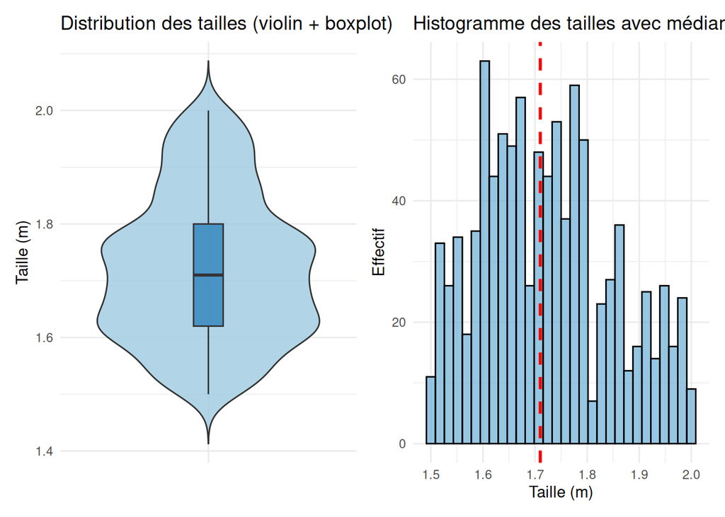

```r
# 1) Violin + boxplot
p_violin_box <- ggplot(SalleDeSport, aes(x = "", y = height)) +
  geom_violin(fill = "#9ECAE1", alpha = 0.8, trim = FALSE) +
  geom_boxplot(width = 0.12, fill = "#3182BD", alpha = 0.8,
               outlier.alpha = 0.6) +
  theme_minimal() +
  labs(
    title = "Distribution des tailles (violin + boxplot)",
    x = NULL,
    y = "Taille (m)"
  ) +
  theme(
    axis.text.x = element_blank(),
    axis.ticks.x = element_blank()
  )

# Calcul de la médiane
med_height <- median(SalleDeSport$height, na.rm = TRUE)

# 2) Histogramme avec médiane
p_hist_med <- ggplot(SalleDeSport, aes(x = height)) +
  geom_histogram(
    bins = 30,
    fill = "#6BAED6",
    color = "black",
    alpha = 0.7
  ) +
  geom_vline(
    xintercept = med_height,
    linetype = "dashed",
    linewidth = 1,
    color = "red"
  ) +
  theme_minimal() +
  labs(
    title = "Histogramme des tailles avec médiane",
    x = "Taille (m)",
    y = "Effectif"
  )

# Affichage côte à côte
p_violin_box | p_hist_med
```

Durée (duration). La médiane est autour de 1,25 h, et la moitié des séances se situe approximativement entre ~1,05 et ~1,45 h. Les durées extrêmes vont d’environ 0,5 h à 2 h. L’histogramme montre une concentration nette entre 1 h et 1,5 h, avec quelques séances plus courtes et plus longues : la variabilité est réelle mais reste dans une plage plausible.

Calories (calories). Le boxplot indique une médiane proche de ~900 kcal, avec un intervalle interquartile environ ~750 à ~1100 kcal. On voit plusieurs valeurs atypiques élevées (au-delà de ~1600–1750 kcal), ce qui indique des séances exceptionnellement énergivores. Cette structure est cohérente avec une distribution asymétrique à droite : beaucoup de séances “standard”, et quelques séances très intenses.

Masse grasse (fat). La médiane est autour de ~26%, avec la majorité des valeurs entre ~21% et ~29%. L’étendue va approximativement de ~10% à ~35%. Le boxplot ne montre pas de points atypiques extrêmes ; l’ensemble semble relativement homogène, avec une dispersion modérée.

IMC (bmi). Le boxplot montre une médiane autour de ~24, avec la moitié des individus approximativement entre ~20 et ~28. En revanche, on observe de nombreux outliers élevés (au-delà de ~40, jusqu’à ~50), ce qui traduit une forte asymétrie à droite : la majorité des individus est dans une zone “classique”, mais une minorité présente des IMC très élevés. Comme l’IMC dépend du poids et de la taille, on s’attend logiquement à un lien fort entre bmi et weight (à confirmer dans l’analyse bi-dimensionnelle/corrélations).

Durée des séances (duration)

L’histogramme montre une forte concentration des séances entre 1 h et 1,5 h, avec quelques séances plus courtes (~0,5 h) et plus longues (~2 h). La distribution est modérément asymétrique, mais reste bien centrée.

Calories brûlées (calories)

La distribution des calories est clairement asymétrique à droite. La majorité des séances se situe entre 700 et 1100 kcal, avec une queue prolongée jusqu’à 1700–1800 kcal, correspondant à des séances très intenses. L’histogramme est unimodal, mais non symétrique.

Choix des bins : Les 30 bins sont très bien adaptés ici :

ils révèlent la forme globale,

tout en conservant la visibilité de la queue à droite. Un nombre plus faible masquerait les extrêmes.

Masse grasse (fat)

La distribution du pourcentage de masse grasse est relativement étalée, entre 10 % et 35 %, avec une concentration principale entre 22 % et 30 %. L’histogramme semble légèrement multimodal, ce qui peut refléter des différences physiologiques (notamment entre genres).

Indice de masse corporelle (bmi)

L’histogramme de l’IMC est fortement asymétrique à droite. La majorité des individus se situe entre 18 et 28, tandis qu’une minorité présente des valeurs très élevées (jusqu’à 50). Cette queue droite importante confirme la présence d’individus en surpoids ou obésité, déjà visible sur le boxplot via de nombreux outliers.

Justification globale du choix du nombre de classes

Dans l’ensemble :

30 bins est un bon compromis pour les variables :

très dispersées (weight, calories, bmi)

ou avec des queues asymétriques marquées

20 bins seraient préférables pour :

height, fat, water

afin de réduire le bruit visuel et améliorer la lisibilité

### Variables qualitatives

On étudie la distribution des variables qualitatives gender et level.

On peut visualiser ces répartitions avec un diagramme en barres ou en secteurs :

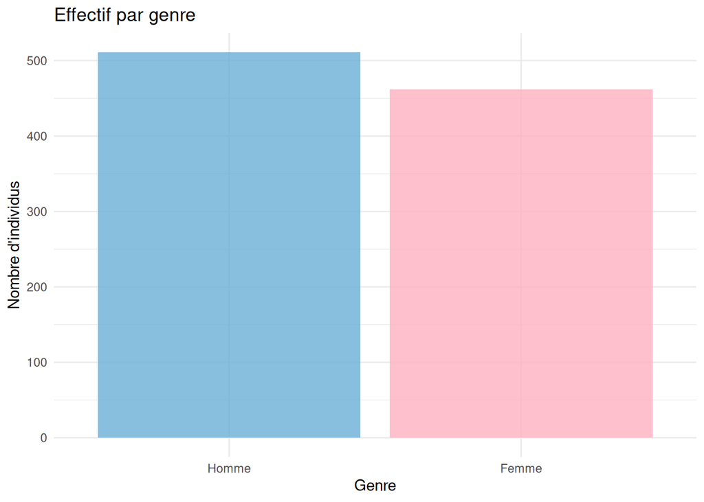

```r
ggplot(SalleDeSport, aes(x=gender, fill=gender)) +
geom_bar(alpha=0.8) +
scale_fill_manual(values=c("#6BAED6","#FDB0C0")) +
labs(title="Effectif par genre", x="Genre", y="Nombre d'individus") +
theme_minimal() + theme(legend.position="none")
```

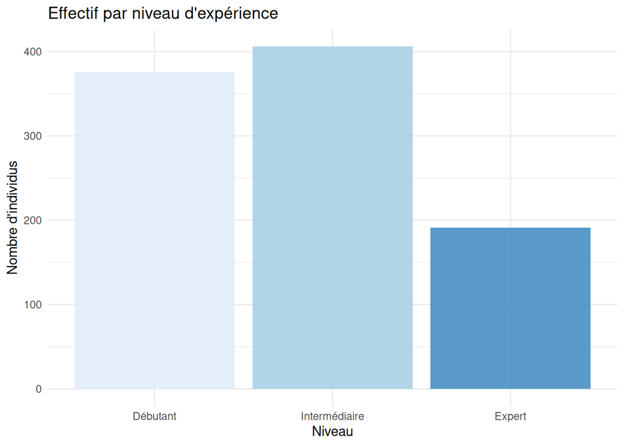

```r
ggplot(SalleDeSport, aes(x=level, fill=level)) +
geom_bar(alpha=0.8) +
scale_fill_brewer(palette="Blues") +
labs(title="Effectif par niveau d'expérience", x="Niveau", y="Nombre d'individus") +
theme_minimal() + theme(legend.position="none")
```

## Analyse multidimentionnelle

On fait quelques geom plot pour commencer a essayer d’observer des trucs dans e jeu de données :

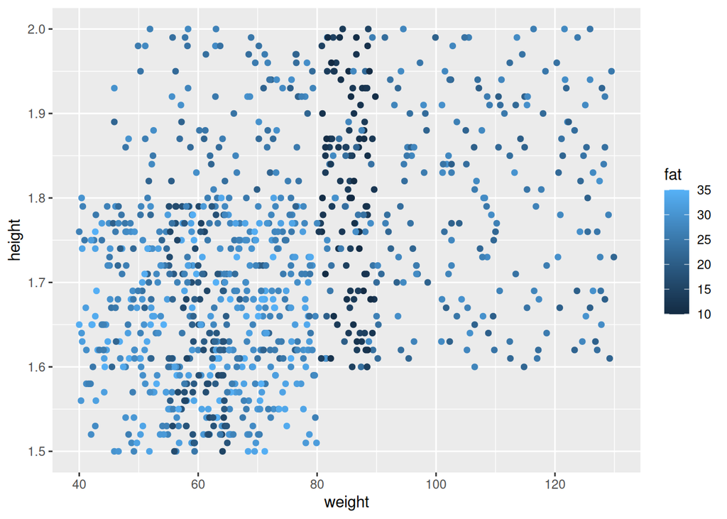

```r
ggplot(data=SalleDeSport)+
   geom_point(aes(x=weight,y=height,color=fat))
```

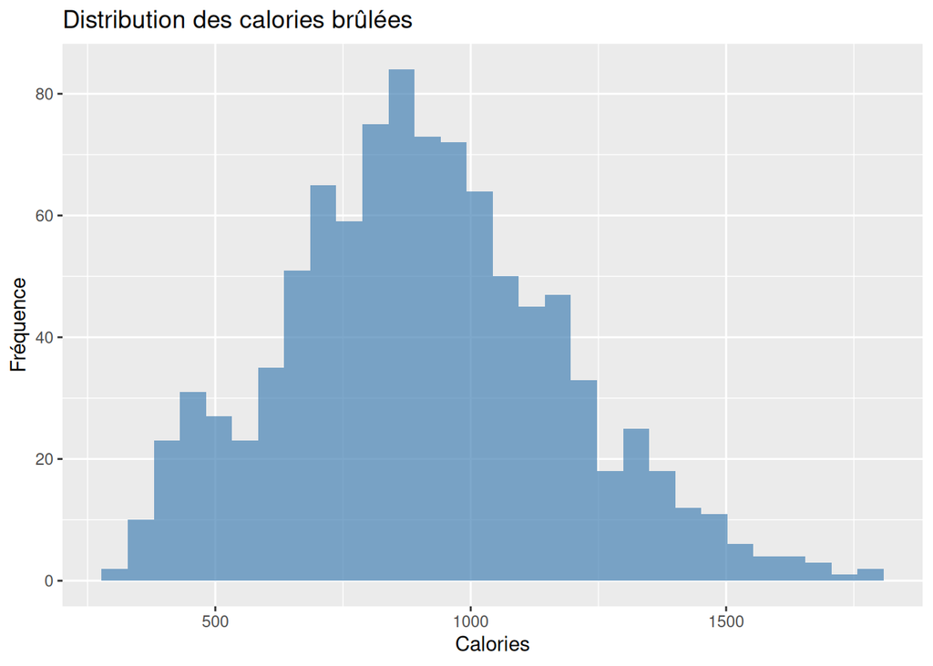

```r
# Histogramme
ggplot(SalleDeSport, aes(x=calories)) +
  geom_histogram(bins=30, fill="steelblue", alpha=0.7) +
  labs(title="Distribution des calories brûlées", x="Calories", y="Fréquence")
```

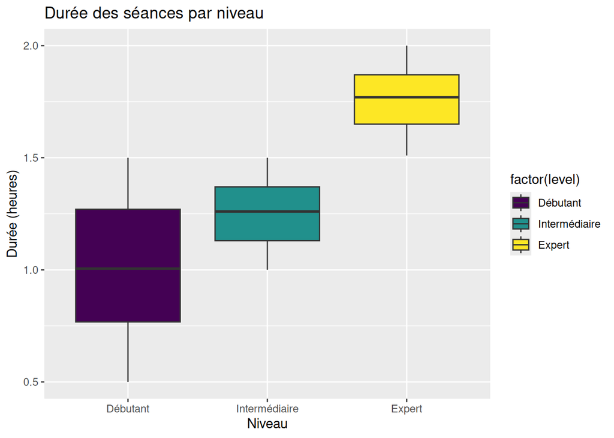

```r
# Boxplot par niveau
ggplot(SalleDeSport, aes(x=factor(level), y=duration, fill=factor(level))) +
  geom_boxplot() +
  labs(title="Durée des séances par niveau", x="Niveau", y="Durée (heures)")
```